# DAB2IP expression among TCGA-BRCA tumor samples

Jeremy M. Simon

12/07/2023

# Overview

The code presented here supports the Mukherjee *et al* publication entitled “DAB2IP-Low Luminal A Breast Cancer Patients Exhibit Gene Expression Profiles Overlapping with More Aggressive Cancer Partly Related to IKK/NF-kB Activation” (2023), *under review*. The steps outlined here recapitulate the analysis performed for preparation of the figures, however, the figures will be subtly different given slight changes in software versions that occurred during manuscript preparation.

The data utilized here were obtained from cBioPortal in February 2019 corresponding to the PanCan Atlas 2018 release and Firehouse Legacy data. The latter contains ER/PR/HER2 status for each patient sample.

Note that the GDC portal no longer includes HTseq gene quantifications but rather includes `augmented_star_gene_counts`, which should be similar, and RNA-seq data also now utilize RSEM whereas the data used here do not.

# Load libraries

```r
library(tidyverse)
```

```r
library(ComplexHeatmap)
library(circlize)
library(tidyHeatmap)
library(readxl)
library(DESeq2)
library(ashr)
library(paletteer)
library(patchwork)
```

# Import ER/PR/HER2 status for all patient samples

```r
EPHstatus <- read_tsv("brca_tcga_clinical_data_ER_PR_HER2.tsv") %>%
    dplyr::select(c(`Sample ID`,`ER Status By IHC`,`IHC-HER2`,`PR status by ihc`)) %>%
    mutate(
        TNBC = case_when(
            `ER Status By IHC` == "Negative" & `IHC-HER2` == "Negative" & `PR status by ihc` == "Negative" ~ "TNBC",
            T ~ "nonTNBC"
            )
        ) %>%
    dplyr::rename("SampleID" = `Sample ID`,
        "ERstatus" = `ER Status By IHC`,
        "HER2status" = `IHC-HER2`,
        "PRstatus" = `PR status by ihc`) %>%
    mutate(SampleID = paste0(SampleID,"A"))
```

[output not shown]

# Import tumor subtype and gene expression values for all patient samples, then compute *DAB2IP* quartiles

```r
Subtype <- read_tsv("data_clinical_patient.txt",skip=4) %>%
    dplyr::rename("SampleID" = PATIENT_ID) %>%
    dplyr::select(c(SampleID,SUBTYPE)) %>%
    mutate(SampleID = paste0(SampleID,"-01A"))
TCGAexpr <- read_tsv("data_RNA_Seq_v2_mRNA_median_all_sample_Zscores.txt") %>%
    dplyr::filter(!is.na(Hugo_Symbol)) %>%
    dplyr::select(!starts_with("Entrez")) %>%
    pivot_longer(cols=!starts_with("Hugo"),names_to="SampleID",values_to="Expression") %>%
    dplyr::rename("Gene" = Hugo_Symbol) %>%
    mutate(SampleID = paste0(SampleID,"A")) %>%
    dplyr::select(c(SampleID,Gene,Expression))
DAB2IP <- TCGAexpr %>%
    dplyr::filter(Gene=="DAB2IP") %>%
    mutate(quartile = ntile(Expression, 4)) %>%
    mutate(
        DAB2IP = case_when(
            quartile == 1 ~ "DAB2IP_low",
            quartile == 4 ~ "DAB2IP_high",
            T ~ "DAB2IP_mid"
            )
        ) %>%
    dplyr::select(SampleID,DAB2IP,Expression)
```

# Combine all data, remove samples whose subtype is missing

```r
combined <- inner_join(inner_join(DAB2IP,EPHstatus),Subtype)
combined <- combined %>%
    drop_na(SUBTYPE)
```

# Plot DAB2IP expression by subtype, boxplots (Fig 1A)

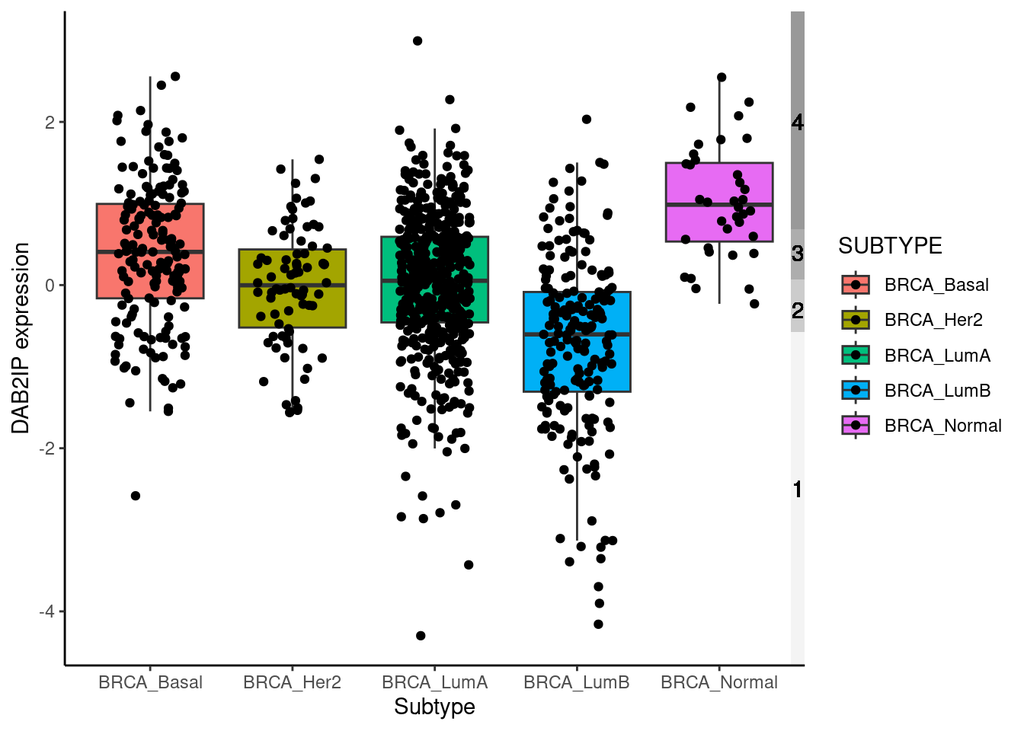

```r
# Get min cutoffs for each DAB2IP expression quartile
DAB2IP.cuts <- TCGAexpr %>%
    filter(Gene=="DAB2IP") %>%
    mutate(quartile = ntile(Expression, 4)) %>%
    group_by(quartile) %>%
    summarize(max = max(Expression)) %>%
    pull(max)

combined %>%
    select(SampleID,Expression,SUBTYPE) %>%
    group_by(SUBTYPE) %>%
    ggplot(aes(x=SUBTYPE,y=Expression,group=SUBTYPE,fill=SUBTYPE)) +
    geom_boxplot(outlier.shape=NA) +
    annotate("rect", xmin=5.5, xmax=Inf, ymin=-Inf, ymax=DAB2IP.cuts[1], alpha=0.4, fill="gray90")  +
    annotate("rect", xmin=5.5, xmax=Inf, ymin=DAB2IP.cuts[1], ymax=DAB2IP.cuts[2], alpha=0.4, fill = "gray50")  +
    annotate("rect", xmin=5.5, xmax=Inf, ymin=DAB2IP.cuts[2], ymax=DAB2IP.cuts[3], alpha=0.4, fill = "gray20")  +
    annotate("rect", xmin=5.5, xmax=Inf, ymin=DAB2IP.cuts[3], ymax=Inf, alpha=0.4, fill = "black")  +
    geom_jitter(width=0.25) +
    ylab("DAB2IP expression") +
    xlab("Subtype") +
    theme_classic() +
    geom_text(label="1",x=5.55,y=-2.5) +
    geom_text(label="2",x=5.55,y=-0.3) +
    geom_text(label="3",x=5.55,y=0.4) +
    geom_text(label="4",x=5.55,y=2)
```

# Import ROR-P scores for all samples

```r
RORP <- read_tsv("BRCA.1218_pam50scores.FINAL.txt") %>%
    dplyr::rename("SampleID" = bcr_patient_barcode, "RORPscores" = `ROR-P (Subtype + Proliferation)`) %>%
    dplyr::select(SampleID,RORPscores) %>%
    mutate(SampleID = paste0(SampleID,"-01A")) %>%
    group_by(SampleID) %>%
    summarize(RORPavg = mean(RORPscores))
```

[output not shown]

# Plot boxplot of RORP by subtype for DAB2IP expression groups

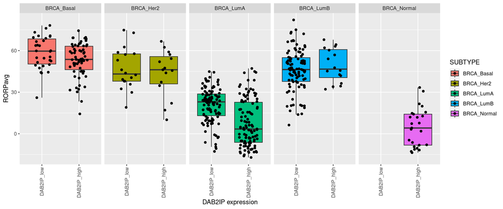

```r
inner_join(TCGAexpr,inner_join(RORP,combined,by="SampleID"),by="SampleID") %>%
    dplyr::select(SampleID,Gene,Expression.x,DAB2IP,Expression.y,ERstatus,SUBTYPE,RORPavg) %>%
    dplyr::rename("Expression" = Expression.x,"DAB2IP_expression" = Expression.y) %>%
    dplyr::filter(Gene=="DAB2IP") %>%
    dplyr::filter(DAB2IP != "DAB2IP_mid") %>%
    ggplot(aes(x=fct_relevel(DAB2IP,c("DAB2IP_low","DAB2IP_high")),y=RORPavg,fill=SUBTYPE)) +
    geom_boxplot(outlier.shape=NA) +
    geom_jitter(width=0.25) +
    xlab("DAB2IP expression") +
    facet_wrap(~SUBTYPE,ncol=5) +
    theme(axis.text.x = element_text(angle = 90, vjust = 0.5, hjust=1))
```

# Compute ROR-P significance between DAB2IP-high and DAB2IP-low groups for each subtype

```r
rorp.d.low.lumA <- inner_join(TCGAexpr,inner_join(RORP,combined,by="SampleID"),by="SampleID") %>%
    dplyr::select(SampleID,Gene,Expression.x,DAB2IP,Expression.y,ERstatus,SUBTYPE,RORPavg) %>%
    dplyr::rename("Expression" = Expression.x,"DAB2IP_expression" = Expression.y) %>%
    dplyr::filter(Gene=="DAB2IP") %>%
    dplyr::filter(SUBTYPE=="BRCA_LumA") %>%
    dplyr::filter(DAB2IP=="DAB2IP_low") %>%
    pull(RORPavg)

rorp.d.high.lumA <- inner_join(TCGAexpr,inner_join(RORP,combined,by="SampleID"),by="SampleID") %>%
    dplyr::select(SampleID,Gene,Expression.x,DAB2IP,Expression.y,ERstatus,SUBTYPE,RORPavg) %>%
    dplyr::rename("Expression" = Expression.x,"DAB2IP_expression" = Expression.y) %>%
    dplyr::filter(Gene=="DAB2IP") %>%
    dplyr::filter(SUBTYPE=="BRCA_LumA") %>%
    dplyr::filter(DAB2IP=="DAB2IP_high") %>%
    pull(RORPavg)

t.test(rorp.d.high.lumA,rorp.d.low.lumA)
```

```
##
##  Welch Two Sample t-test
##
## data:  rorp.d.high.lumA and rorp.d.low.lumA
## t = -6.6269, df = 201.56, p-value = 3.064e-10
## alternative hypothesis: true difference in means is not equal to 0
## 95 percent confidence interval:
##  -17.189772  -9.306095
## sample estimates:
## mean of x mean of y
##  7.464012 20.711945
```

```r
rorp.d.low.lumB <- inner_join(TCGAexpr,inner_join(RORP,combined,by="SampleID"),by="SampleID") %>%
    dplyr::select(SampleID,Gene,Expression.x,DAB2IP,Expression.y,ERstatus,SUBTYPE,RORPavg) %>%
    dplyr::rename("Expression" = Expression.x,"DAB2IP_expression" = Expression.y) %>%
    dplyr::filter(Gene=="DAB2IP") %>%
    dplyr::filter(SUBTYPE=="BRCA_LumB") %>%
    dplyr::filter(DAB2IP=="DAB2IP_low") %>%
    pull(RORPavg)

rorp.d.high.lumB <- inner_join(TCGAexpr,inner_join(RORP,combined,by="SampleID"),by="SampleID") %>%
    dplyr::select(SampleID,Gene,Expression.x,DAB2IP,Expression.y,ERstatus,SUBTYPE,RORPavg) %>%
 dplyr::    rename("Expression" = Expression.x,"DAB2IP_expression" = Expression.y) %>%
    dplyr::filter(Gene=="DAB2IP") %>%
    dplyr::filter(SUBTYPE=="BRCA_LumB") %>%
    dplyr::filter(DAB2IP=="DAB2IP_high") %>%
    pull(RORPavg)

t.test(rorp.d.high.lumB,rorp.d.low.lumB)
```

```
##
##  Welch Two Sample t-test
##
## data:  rorp.d.high.lumB and rorp.d.low.lumB
## t = 0.96542, df = 23.001, p-value = 0.3444
## alternative hypothesis: true difference in means is not equal to 0
## 95 percent confidence interval:
##  -3.704416 10.187711
## sample estimates:
## mean of x mean of y
##  49.27263  46.03098
```

```r
rorp.d.low.Basal <- inner_join(TCGAexpr,inner_join(RORP,combined,by="SampleID"),by="SampleID") %>%
    dplyr::select(SampleID,Gene,Expression.x,DAB2IP,Expression.y,ERstatus,SUBTYPE,RORPavg) %>%
    dplyr::rename("Expression" = Expression.x,"DAB2IP_expression" = Expression.y) %>%
    dplyr::filter(Gene=="DAB2IP") %>%
    dplyr::filter(SUBTYPE=="BRCA_Basal") %>%
    dplyr::filter(DAB2IP=="DAB2IP_low") %>%
    pull(RORPavg)

rorp.d.high.Basal <- inner_join(TCGAexpr,inner_join(RORP,combined,by="SampleID"),by="SampleID") %>%
    dplyr::select(SampleID,Gene,Expression.x,DAB2IP,Expression.y,ERstatus,SUBTYPE,RORPavg) %>%
    dplyr::rename("Expression" = Expression.x,"DAB2IP_expression" = Expression.y) %>%
    dplyr::filter(Gene=="DAB2IP") %>%
    dplyr::filter(SUBTYPE=="BRCA_Basal") %>%
    dplyr::filter(DAB2IP=="DAB2IP_high") %>%
    pull(RORPavg)

t.test(rorp.d.high.Basal,rorp.d.low.Basal)
```

```
##
##  Welch Two Sample t-test
##
## data:  rorp.d.high.Basal and rorp.d.low.Basal
## t = -2.0816, df = 59.824, p-value = 0.04167
## alternative hypothesis: true difference in means is not equal to 0
## 95 percent confidence interval:
##  -10.8012654  -0.2147586
## sample estimates:
## mean of x mean of y
##  53.06848  58.57649
```

```r
rorp.d.low.Her2 <- inner_join(TCGAexpr,inner_join(RORP,combined,by="SampleID"),by="SampleID") %>%
    dplyr::select(SampleID,Gene,Expression.x,DAB2IP,Expression.y,ERstatus,SUBTYPE,RORPavg) %>%
    dplyr::rename("Expression" = Expression.x,"DAB2IP_expression" = Expression.y) %>%
    dplyr::filter(Gene=="DAB2IP") %>%
    dplyr::filter(SUBTYPE=="BRCA_Her2") %>%
    dplyr::filter(DAB2IP=="DAB2IP_low") %>%
    pull(RORPavg)

rorp.d.high.Her2 <- inner_join(TCGAexpr,inner_join(RORP,combined,by="SampleID"),by="SampleID") %>%
    dplyr::select(SampleID,Gene,Expression.x,DAB2IP,Expression.y,ERstatus,SUBTYPE,RORPavg) %>%
    dplyr::rename("Expression" = Expression.x,"DAB2IP_expression" = Expression.y) %>%
    dplyr::filter(Gene=="DAB2IP") %>%
    dplyr::filter(SUBTYPE=="BRCA_Her2") %>%
    dplyr::filter(DAB2IP=="DAB2IP_high") %>%
    pull(RORPavg)

t.test(rorp.d.high.Her2,rorp.d.low.Her2)
```

```
##
##  Welch Two Sample t-test
##
## data:  rorp.d.high.Her2 and rorp.d.low.Her2
## t = -0.54965, df = 28.418, p-value = 0.5869
## alternative hypothesis: true difference in means is not equal to 0
## 95 percent confidence interval:
##  -14.479670   8.349809
## sample estimates:
## mean of x mean of y
##  43.70862  46.77355
```

# Select DAB2IP-high and DAB2IP-low ER+ LumA tumors for differential expression analysis

```r
tumorsDE <- combined %>%
    dplyr::select(SampleID,DAB2IP,ERstatus,SUBTYPE) %>%
    dplyr::filter(ERstatus=="Positive") %>%
    dplyr::filter(SUBTYPE=="BRCA_LumA") %>%
    dplyr::filter(DAB2IP!="DAB2IP_mid")
write_tsv(tumorsDE,"TCGA_BRCA_tumors_DAB2IP_low_high_ERpositiveOnly_LumA_120723.tsv")

tumorsDE
```

```
## # A tibble: 206 × 4
##    SampleID         DAB2IP      ERstatus SUBTYPE
##    <chr>            <chr>       <chr>    <chr>
##  1 TCGA-3C-AAAU-01A DAB2IP_high Positive BRCA_LumA
##  2 TCGA-4H-AAAK-01A DAB2IP_high Positive BRCA_LumA
##  3 TCGA-A1-A0SE-01A DAB2IP_high Positive BRCA_LumA
##  4 TCGA-A1-A0SQ-01A DAB2IP_high Positive BRCA_LumA
##  5 TCGA-A2-A04V-01A DAB2IP_high Positive BRCA_LumA
##  6 TCGA-A2-A0CK-01A DAB2IP_high Positive BRCA_LumA
##  7 TCGA-A2-A0CP-01A DAB2IP_high Positive BRCA_LumA
##  8 TCGA-A2-A0CR-01A DAB2IP_high Positive BRCA_LumA
##  9 TCGA-A2-A0CT-01A DAB2IP_low  Positive BRCA_LumA
## 10 TCGA-A2-A0CV-01A DAB2IP_high Positive BRCA_LumA
## # … with 196 more rows
```

# Run DESeq2 comparing DAB2IP-high and DAB2IP-low ER+ LumA tumors

```r
# Collapse all htseq output files from isoform->gene
tx2gene <- read_tsv("rawCounts_DE/gencode.gene.info.v22.lookup.tsv",col_names=c("tx","gene"))

sampleFiles <- grep("htseq.counts$",list.files("rawCounts_DE"),value=TRUE)
for (i in 1:length(sampleFiles)) {
    file <- sampleFiles[i]
    tsv <- read_tsv(paste0("rawCounts_DE/",file),col_names=c("tx","count"))
    joined <- inner_join(tsv,tx2gene) %>%
        group_by(gene) %>%
        summarize(sum = sum(count))
    newFile <- paste0("rawCounts_DE/",file,".030323.collapsed")
    write_tsv(joined,newFile,col_names=F)
}
```

```r
# Join sample IDs with filenames of new collapsed counts files and compile DESeq2 metadata
sampleFiles <- grep("counts.030323.collapsed",list.files("rawCounts_DE"),value=TRUE)
sampleInfo <- read_tsv("TCGA_BRCA_tumors_DAB2IP_low_high_ERpositiveOnly_LumA_120723.tsv")
countFiles <- read_tsv("rawCounts_DE/gdc_sample_sheet.2020-11-25.tsv") %>%
    dplyr::select(`Sample ID`,`File Name`) %>%
    dplyr::rename("SampleID" = `Sample ID`,"Filename" = `File Name`)
coldata <- inner_join(sampleInfo,countFiles) %>%
    dplyr::select(SampleID,Filename,DAB2IP) %>%
    mutate(Filename = str_replace_all(Filename,"counts.gz","counts.030323.collapsed")) %>%
    dplyr::filter(Filename != "0c7d119e-22c0-47ed-b736-3404ab2c7065.htseq.counts.030323.collapsed") %>%
    dplyr::filter(Filename != "6aa69f7f-28c6-4943-b907-62d8085e9c6c.htseq.counts.030323.collapsed")
        # These two samples have two counts files, removing the second instance of both

coldata <- as.data.frame(coldata)
coldata$DAB2IP <- factor(coldata$DAB2IP)


# Set up DESeq2 object
dds <- DESeqDataSetFromHTSeqCount(sampleTable = coldata, directory = "rawCounts_DE", design= ~DAB2IP)

# Run DE test
dds <- DESeq(dds,betaPrior=FALSE)
```

```
## -- replacing outliers and refitting for 4830 genes
## -- DESeq argument 'minReplicatesForReplace' = 7
## -- original counts are preserved in counts(dds)
```

```r
# Use shrunken log-fold-changes with `ashr`
res <- lfcShrink(dds, contrast=c("DAB2IP","DAB2IP_high","DAB2IP_low"), type="ashr")
```

```
## using 'ashr' for LFC shrinkage. If used in published research, please cite:
##     Stephens, M. (2016) False discovery rates: a new deal. Biostatistics, 18:2.
##     https://doi.org/10.1093/biostatistics/kxw041
```

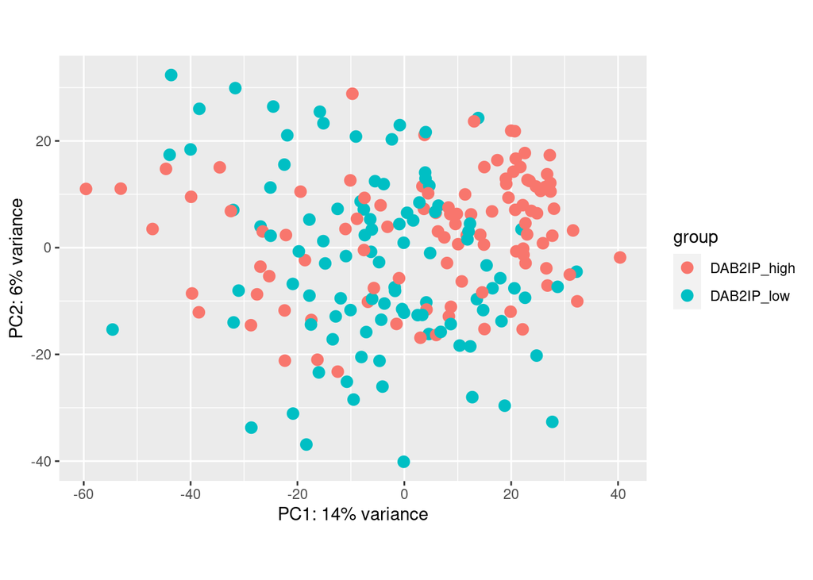

```r
# VST normalization for downstream plotting
vsd <- vst(dds)
DESeq2::plotPCA(vsd, intgroup="DAB2IP")
```

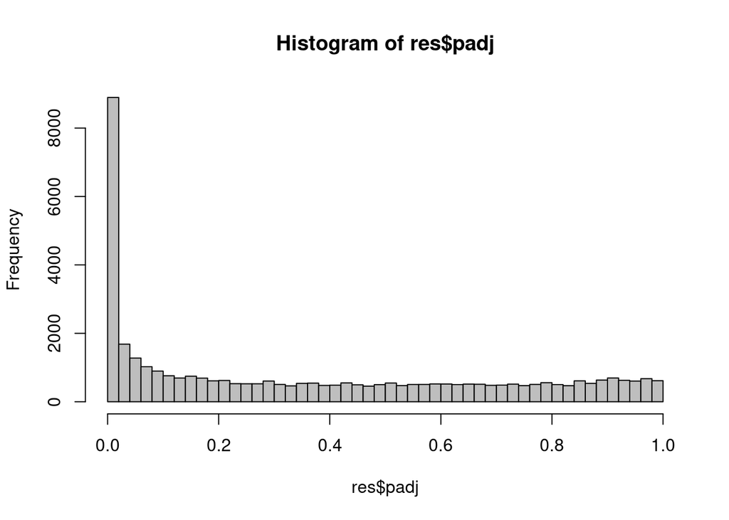

```r
# Prepare output files
res <- res[order(res$padj), ]
resdata <- merge(as.data.frame(res,row.names=rownames(res)), as.data.frame(assay(vsd)), by="row.names", sort=FALSE)
rownames(resdata)=resdata$Row.names
resdata=resdata[,-1]

# Plot histogram of significant adjusted p-values
hist(res$padj, breaks=50, col="grey")
```

```r
# Filter results
res_tbl <- rownames_to_column(as.data.frame(res), var = "Gene") %>%
    as_tibble()

res_filt <- res_tbl %>%
    dplyr::select(Gene,log2FoldChange,padj) %>%
    dplyr::filter(padj<1e-10)

# Write output
write_tsv(res_filt,"TCGA_BRCA_tumors_DAB2IP_low_high_ERpositiveOnly_LumA_DESeq2_results_adjP1e10_120723.txt")
```

# Read in DE results DAB2IP low/high ER+ LumA tumors

```r
DEG <- read_tsv("TCGA_BRCA_tumors_DAB2IP_low_high_ERpositiveOnly_LumA_DESeq2_results_adjP1e10_120723.txt")
DEG_any <- DEG %>%
    pull(Gene)

# Subset TCGA gene expression data to just the differentially-expressed genes
TCGAexpr_DEG <- TCGAexpr %>%
    dplyr::filter(Gene %in% DEG_any)
```

# Create manual ordering of tumors by subtype then by DAB2IP expression (Fig 3A)

```r
DAB2IP_order <- inner_join(TCGAexpr_DEG,combined,by="SampleID") %>%
    dplyr::select(SampleID,Gene,Expression.x,DAB2IP,Expression.y,ERstatus,SUBTYPE) %>%
    dplyr::rename("Expression" = Expression.x,"DAB2IP_expression" = Expression.y) %>%
    dplyr::filter(!is.na(SUBTYPE)) %>%
    dplyr::filter(ERstatus=="Positive" | ERstatus=="Negative") %>%
    dplyr::filter(DAB2IP=="DAB2IP_high" | DAB2IP=="DAB2IP_low") %>%
    group_by(SUBTYPE) %>%
    dplyr::arrange(DAB2IP_expression,.by_group = T) %>%
    dplyr::select(SampleID,DAB2IP_expression) %>%
    unique() %>%
    pull(SampleID)
```

```
## tidyHeatmap says: (once per session) from release 1.7.0 the scaling is set to "none" by default. Please use scale = "row", "column" or "both" to apply scaling
```

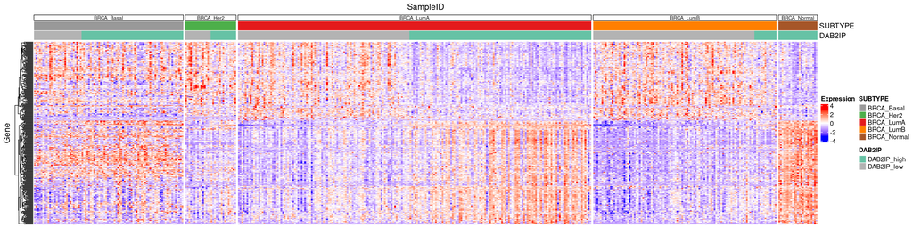

```r
# Now plot heatmap of DAB2IP DEGs for all DAB2IP high/low tumors
inner_join(TCGAexpr_DEG,combined,by="SampleID") %>%
    dplyr::select(SampleID,Gene,Expression.x,DAB2IP,Expression.y,ERstatus,SUBTYPE) %>%
    dplyr::rename("Expression" = Expression.x,"DAB2IP_expression" = Expression.y) %>%
    dplyr::filter(DAB2IP=="DAB2IP_high" | DAB2IP=="DAB2IP_low") %>%
    dplyr::filter(!is.na(SUBTYPE)) %>%
    dplyr::filter(ERstatus=="Positive" | ERstatus=="Negative") %>%
    group_by(SUBTYPE) %>%
    tidyHeatmap::heatmap(Gene,
        SampleID,
        Expression,
        scale="none",
        palette_value=colorRamp2(c(-3, 0, 3), c("blue", "white", "red")),
        cluster_columns=F,
        column_order=DAB2IP_order,
        show_row_names = FALSE,
        show_column_names = FALSE) %>%
    add_tile(SUBTYPE) %>%
    add_tile(DAB2IP)
```

# Explore pairwise correlation of tumors based on DEG expression profiles

```r
# Format sample metadata
coldata <- inner_join(TCGAexpr_DEG,combined,by="SampleID") %>%
    dplyr::select(SampleID,Gene,Expression.x,DAB2IP,Expression.y,ERstatus,SUBTYPE) %>%
    dplyr::rename("Expression" = Expression.x,"DAB2IP_expression" = Expression.y) %>%
    dplyr::filter(DAB2IP=="DAB2IP_high" | DAB2IP=="DAB2IP_low") %>%
    dplyr::filter(!is.na(SUBTYPE)) %>%
    dplyr::filter(ERstatus=="Positive" | ERstatus=="Negative") %>%
    dplyr::filter(Gene=="DAB2IP") %>%
    dplyr::select(-Gene,-DAB2IP_expression,-Expression) %>%
    mutate(SUBTYPE = str_replace_all(SUBTYPE,"BRCA_","")) %>%
    unite(Group,c(SUBTYPE,DAB2IP),sep="_")

coldata.df <- as.data.frame(column_to_rownames(coldata,var="SampleID"))

# Format expression data matrix
degmat <- inner_join(TCGAexpr_DEG,combined,by="SampleID") %>%
    dplyr::select(SampleID,Gene,Expression.x,DAB2IP,Expression.y,ERstatus,SUBTYPE) %>%
    dplyr::rename("Expression" = Expression.x,"DAB2IP_expression" = Expression.y) %>%
    dplyr::filter(DAB2IP=="DAB2IP_high" | DAB2IP=="DAB2IP_low") %>%
    dplyr::filter(!is.na(SUBTYPE)) %>%
    dplyr::filter(ERstatus=="Positive" | ERstatus=="Negative") %>%
    dplyr::select(-DAB2IP,-DAB2IP_expression,-ERstatus,-SUBTYPE) %>%
    pivot_wider(names_from=SampleID,values_from=Expression,values_fn = median)

degmat.df <- as.data.frame(column_to_rownames(degmat,var="Gene"))

# Compute Pearson correlations, Luminal A DAB2IP-low vs all
cors <- cor(degmat.df[,coldata$SampleID[coldata$Group=="LumA_DAB2IP_low"]],degmat.df)
```

# Plot correlation heatmap (Fig 3B)

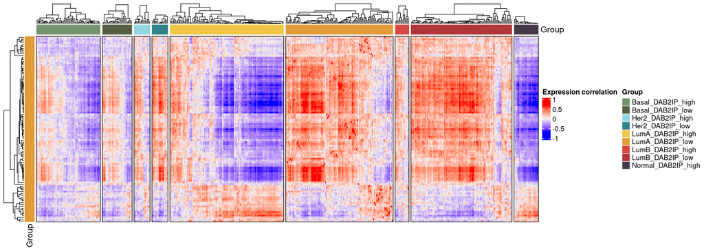

```r
# Set up sample groupings and colors
cols <- c(paletteer_d("nationalparkcolors::Redwoods")[1],       # Light green
      paletteer_d("nationalparkcolors::Everglades")[5],     # Dark green
      paletteer_d("nationalparkcolors::Everglades")[1],     # Light blue
      paletteer_d("nationalparkcolors::Everglades")[2],     # Dark blue
      paletteer_d("nationalparkcolors::Redwoods")[3],       # Light yellow
      paletteer_d("nationalparkcolors::BryceCanyon")[1],        # Dark yellow
      paletteer_d("nationalparkcolors::Badlands")[3],       # Light red
      paletteer_d("nationalparkcolors::DeathValley")[1],        # Dark red
      paletteer_d("nationalparkcolors::Acadia")[6]      # Dark gray
)

names(cols) <- levels(as.factor(coldata$Group))

ha1 <- HeatmapAnnotation(Group = as.factor(coldata$Group), col = list(Group = cols))
ha2 <- rowAnnotation(Group = as.factor(coldata$Group[coldata$Group %in% "LumA_DAB2IP_low"]), col = list(Group = cols), show_legend = F)

# Plot such that DAB2IP_low_LumA (rows) plotted in same order as the clustered columns
# Plot once to get column orders, then plot again with those specified to order the rows

h1 <- ComplexHeatmap::Heatmap(cors,
    show_row_names = F,
    show_column_names = F,
    name = "Expression correlation",
    clustering_distance_rows=function(x) as.dist(1-cor(t(x))),
    clustering_method_rows = "complete",
    clustering_distance_columns=function(x) as.dist(1-cor(t(x))),
    clustering_method_columns = "complete",
    column_title = NULL,
    row_title = NULL,
    top_annotation = ha1,
    left_annotation = ha2,
    cluster_column_slices = F,
    column_split = as.factor(coldata$Group),
    border = T
)

# Draw unordered version to get order
ht <- draw(h1)
```

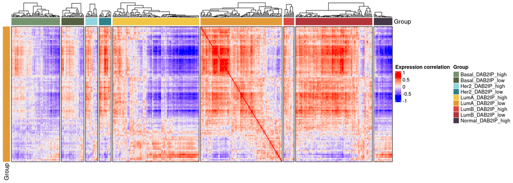

```r
orders = column_order(ht)
row_order <- orders$LumA_DAB2IP_low

# Draw in sorted order
ComplexHeatmap::Heatmap(cors[colnames(cors)[row_order],],
    show_row_names = F,
    show_column_names = F,
    cluster_rows = F,
    name = "Expression correlation",
    clustering_distance_columns=function(x) as.dist(1-cor(t(x))),
    clustering_method_columns = "complete",
    column_title = NULL,
    row_title = NULL,
    top_annotation = ha1,
    left_annotation = ha2,
    cluster_column_slices = F,
    column_split = as.factor(coldata$Group),
    border = T
)
```

# Plot Proliferation scores for each tumor based on 11-gene panel (Fig 4A)

```r
PDscores <- read_tsv("TCGA_Dscore_Pscore.txt")
```

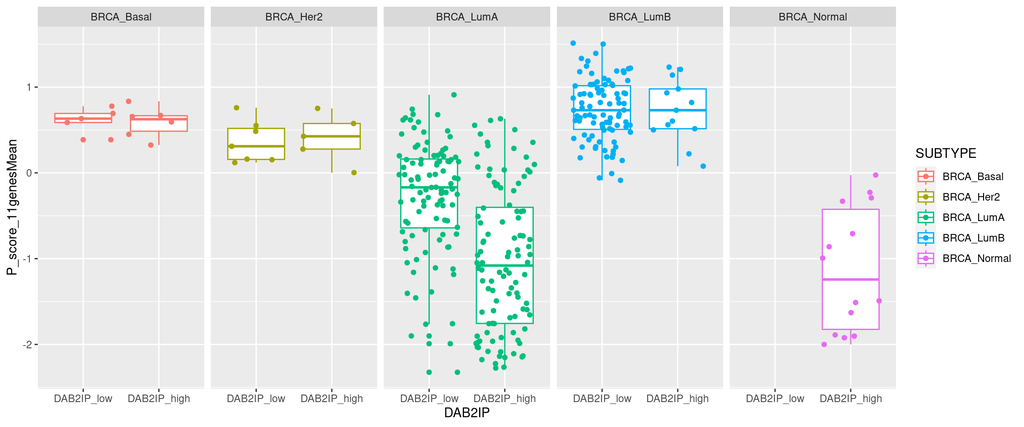

```r
left_join(combined,PDscores) %>%
    dplyr::select(SampleID,ERstatus,SUBTYPE,D_Score,P_score_11genesMean,Expression,DAB2IP) %>%
    dplyr::filter(ERstatus=="Positive") %>%
    drop_na(SUBTYPE) %>%
    drop_na(P_score_11genesMean) %>%
    dplyr::filter(DAB2IP!="DAB2IP_mid") %>%
    mutate(DAB2IP = fct_relevel(DAB2IP,c("DAB2IP_low","DAB2IP_high"))) %>%
    ggplot(aes(x=DAB2IP,y=P_score_11genesMean,color=SUBTYPE)) +
    geom_boxplot() +
    geom_jitter() +
    facet_wrap(~SUBTYPE,ncol=5)
```

# Compute significance for Proliferation scores for each subtype

```r
# LumA
Pscore_LumA_low <- left_join(combined,PDscores) %>%
    dplyr::select(SampleID,ERstatus,SUBTYPE,D_Score,P_score_11genesMean,Expression,DAB2IP) %>%
    dplyr::filter(ERstatus=="Positive") %>%
    drop_na(SUBTYPE) %>%
    dplyr::filter(DAB2IP=="DAB2IP_low" & SUBTYPE=="BRCA_LumA") %>%
    pull(P_score_11genesMean)
Pscore_LumA_high <- left_join(combined,PDscores) %>%
    dplyr::select(SampleID,ERstatus,SUBTYPE,D_Score,P_score_11genesMean,Expression,DAB2IP) %>%
    dplyr::filter(ERstatus=="Positive") %>%
    drop_na(SUBTYPE) %>%
    dplyr::filter(DAB2IP=="DAB2IP_high" & SUBTYPE=="BRCA_LumA") %>%
    pull(P_score_11genesMean)
t.test(Pscore_LumA_low,Pscore_LumA_high)
```

```
##
##  Welch Two Sample t-test
##
## data:  Pscore_LumA_low and Pscore_LumA_high
## t = 7.1667, df = 194.46, p-value = 1.555e-11
## alternative hypothesis: true difference in means is not equal to 0
## 95 percent confidence interval:
##  0.5406667 0.9512256
## sample estimates:
## mean of x mean of y
## -0.267900 -1.013846
```

```r
# LumB
Pscore_LumB_low <- left_join(combined,PDscores) %>%
    dplyr::select(SampleID,ERstatus,SUBTYPE,D_Score,P_score_11genesMean,Expression,DAB2IP) %>%
    dplyr::filter(ERstatus=="Positive") %>%
    drop_na(SUBTYPE) %>%
    dplyr::filter(DAB2IP=="DAB2IP_low" & SUBTYPE=="BRCA_LumB") %>%
    pull(P_score_11genesMean)
Pscore_LumB_high <- left_join(combined,PDscores) %>%
    dplyr::select(SampleID,ERstatus,SUBTYPE,D_Score,P_score_11genesMean,Expression,DAB2IP) %>%
    dplyr::filter(ERstatus=="Positive") %>%
    drop_na(SUBTYPE) %>%
    dplyr::filter(DAB2IP=="DAB2IP_high" & SUBTYPE=="BRCA_LumB") %>%
    pull(P_score_11genesMean)
t.test(Pscore_LumB_low,Pscore_LumB_high)
```

```
##
##  Welch Two Sample t-test
##
## data:  Pscore_LumB_low and Pscore_LumB_high
## t = 0.017274, df = 15.495, p-value = 0.9864
## alternative hypothesis: true difference in means is not equal to 0
## 95 percent confidence interval:
##  -0.2266552  0.2303695
## sample estimates:
## mean of x mean of y
## 0.7344341 0.7325769
```

```r
# Basal
Pscore_Basal_low <- left_join(combined,PDscores) %>%
    dplyr::select(SampleID,ERstatus,SUBTYPE,D_Score,P_score_11genesMean,Expression,DAB2IP) %>%
    dplyr::filter(ERstatus=="Positive") %>%
    drop_na(SUBTYPE) %>%
    dplyr::filter(DAB2IP=="DAB2IP_low" & SUBTYPE=="BRCA_Basal") %>%
    pull(P_score_11genesMean)
Pscore_Basal_high <- left_join(combined,PDscores) %>%
    dplyr::select(SampleID,ERstatus,SUBTYPE,D_Score,P_score_11genesMean,Expression,DAB2IP) %>%
    dplyr::filter(ERstatus=="Positive") %>%
    drop_na(SUBTYPE) %>%
    dplyr::filter(DAB2IP=="DAB2IP_high" & SUBTYPE=="BRCA_Basal") %>%
    pull(P_score_11genesMean)
t.test(Pscore_Basal_low,Pscore_Basal_high)
```

```
##
##  Welch Two Sample t-test
##
## data:  Pscore_Basal_low and Pscore_Basal_high
## t = 0.27631, df = 9, p-value = 0.7885
## alternative hypothesis: true difference in means is not equal to 0
## 95 percent confidence interval:
##  -0.1950053  0.2492719
## sample estimates:
## mean of x mean of y
## 0.6153000 0.5881667
```

```r
# Her2
Pscore_Her2_low <- left_join(combined,PDscores) %>%
    dplyr::select(SampleID,ERstatus,SUBTYPE,D_Score,P_score_11genesMean,Expression,DAB2IP) %>%
    dplyr::filter(ERstatus=="Positive") %>%
    drop_na(SUBTYPE) %>%
    dplyr::filter(DAB2IP=="DAB2IP_low" & SUBTYPE=="BRCA_Her2") %>%
    pull(P_score_11genesMean)
Pscore_Her2_high <- left_join(combined,PDscores) %>%
    dplyr::select(SampleID,ERstatus,SUBTYPE,D_Score,P_score_11genesMean,Expression,DAB2IP) %>%
    dplyr::filter(ERstatus=="Positive") %>%
    drop_na(SUBTYPE) %>%
    dplyr::filter(DAB2IP=="DAB2IP_high" & SUBTYPE=="BRCA_Her2") %>%
    pull(P_score_11genesMean)
t.test(Pscore_Her2_low,Pscore_Her2_high)
```

```
##
##  Welch Two Sample t-test
##
## data:  Pscore_Her2_low and Pscore_Her2_high
## t = -0.27922, df = 7.811, p-value = 0.7873
## alternative hypothesis: true difference in means is not equal to 0
## 95 percent confidence interval:
##  -0.4086571  0.3207142
## sample estimates:
## mean of x mean of y
## 0.3629286 0.4069000
```

# Plot heatmap of differentially expressed genes that represent putative NF-kB (RelA) targets (Fig 7A)

These putative targets were identified using [ChIP-Atlas](http://chip-atlas.org/). Signal within 5kb of the transcription start site (TSS) of target genes was averaged for HMEC, MCF7, and MDA-MB-231 cells (n=20 studies total), and filtered to retain promoters with signal greater than or equal to 10

```r
rela_targets <- read_tsv("RELA.5.breast.gt10.tsv",col_names="Gene") %>%
    pull(Gene)
```

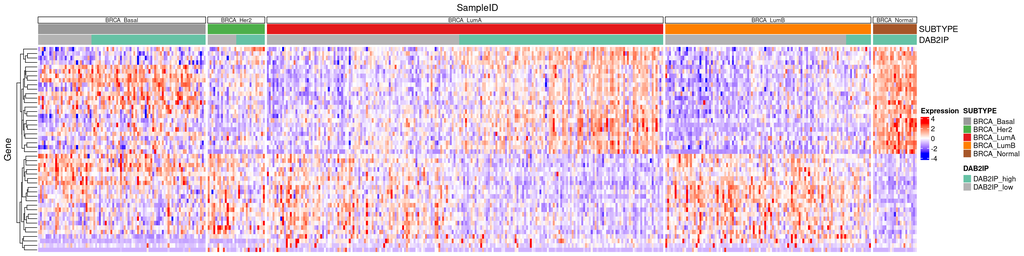

```r
inner_join(TCGAexpr_DEG,combined,by="SampleID") %>%
    dplyr::select(SampleID,Gene,Expression.x,DAB2IP,Expression.y,ERstatus,SUBTYPE) %>%
    dplyr::rename("Expression" = Expression.x,"DAB2IP_expression" = Expression.y) %>%
    dplyr::filter(DAB2IP=="DAB2IP_high" | DAB2IP=="DAB2IP_low") %>%
    dplyr::filter(!is.na(SUBTYPE)) %>%
    dplyr::filter(ERstatus=="Positive" | ERstatus=="Negative") %>%
    dplyr::filter(Gene %in% rela_targets) %>%
    group_by(SUBTYPE) %>%
    tidyHeatmap::heatmap(Gene,
        SampleID,
        Expression,
        scale="none",
        palette_value=colorRamp2(c(-3, 0, 3), c("blue", "white", "red")),
        cluster_columns=F,
        column_order=DAB2IP_order,
        show_row_names = FALSE,
        show_column_names = FALSE) %>%
    add_tile(SUBTYPE) %>%
    add_tile(DAB2IP)
```

# Plot four putative target genes expression for each subtype split by DAB2IP status (Fig 7B)

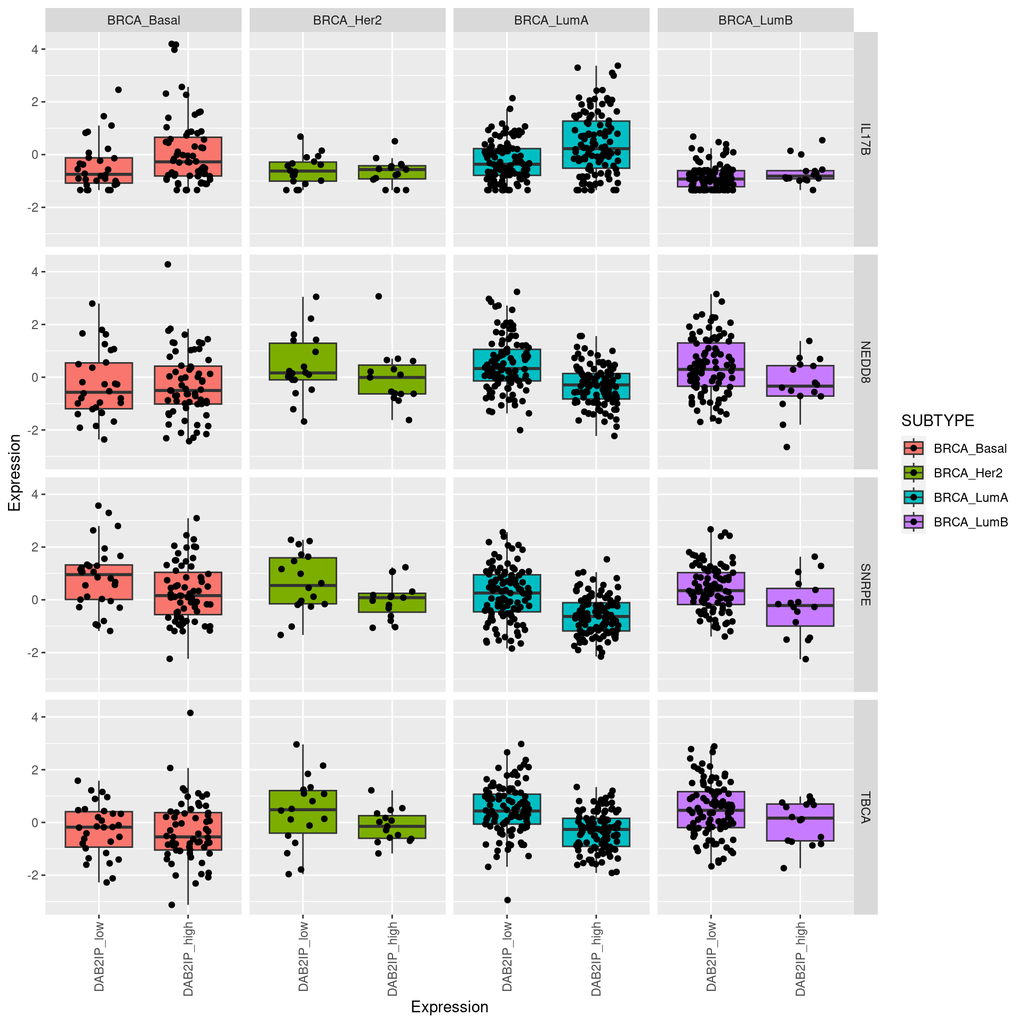

```r
goi <- c("NEDD8", "IL17B", "SNRPE", "TBCA")

inner_join(TCGAexpr_DEG,combined,by="SampleID") %>%
    dplyr::filter(Gene %in% goi) %>%
    dplyr::select(SampleID,Gene,Expression.x,DAB2IP,Expression.y,ERstatus,SUBTYPE) %>%
    dplyr::rename("Expression" = Expression.x,"DAB2IP_expression" = Expression.y) %>%
    dplyr::filter(SUBTYPE != "BRCA_Normal") %>%
    dplyr::filter(DAB2IP != "DAB2IP_mid") %>%
    ggplot(aes(x=fct_relevel(DAB2IP,c("DAB2IP_low","DAB2IP_high")),y=Expression,fill=SUBTYPE)) +
    geom_boxplot(outlier.shape=NA) +
    geom_jitter(width=0.25) +
    xlab("Expression") +
    facet_grid(Gene~SUBTYPE) +
    theme(axis.text.x = element_text(angle = 90, vjust = 0.5, hjust=1))
```

# Plot heatmap of differentially expressed KEGG spliceosome genes (Fig 7D)

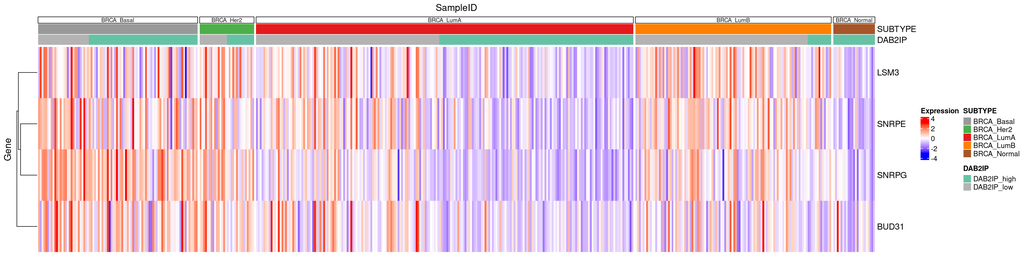

```r
kegg.splice.genes <- c("SNRPE","SRSF1","SNRPG","SRSF2","SNRPD1","SNRPF","BUD31","MAGOHB","HNRNPU","HNRNPC","SNRPB2","ALYREF","SNRPC","SF3B6","SNRNP27","SNRPA1","USP39","PPIL1","LSM3","SNRPB")

inner_join(TCGAexpr_DEG,combined,by="SampleID") %>%
    dplyr::select(SampleID,Gene,Expression.x,DAB2IP,Expression.y,ERstatus,SUBTYPE) %>%
    dplyr::filter(Gene %in% kegg.splice.genes) %>%
    dplyr::rename("Expression" = Expression.x,"DAB2IP_expression" = Expression.y) %>%
    dplyr::filter(DAB2IP=="DAB2IP_high" | DAB2IP=="DAB2IP_low") %>%
    dplyr::filter(!is.na(SUBTYPE)) %>%
    dplyr::filter(ERstatus=="Positive" | ERstatus=="Negative") %>%
    group_by(SUBTYPE) %>%
    tidyHeatmap::heatmap(Gene,
        SampleID,
        Expression,
        scale="none",
        palette_value=colorRamp2(c(-3, 0, 3), c("blue", "white", "red")),
        cluster_columns=F,
        column_order=DAB2IP_order,
        show_row_names = T,
        show_column_names = FALSE) %>%
    add_tile(SUBTYPE) %>%
    add_tile(DAB2IP)
```

# Save workspace

```r
save.image("TCGA-BRCA_DAB2IP_120723.RData")
```